# Pei_Final

```r
print.psych(pca_final, cut = 0.3, sort = TRUE)
```

```
## Principal Components Analysis
## Call: principal(r = scaled_score_sport, nfactors = 4, rotate = "promax")
## Standardized loadings (pattern matrix) based upon correlation matrix
##                        item   RC1   RC3   RC2   RC4   h2    u2 com
## ACTCM75                  15  1.01                   0.91 0.091 1.0
## ACTCM25                  14  1.00                   0.95 0.050 1.0
## ACTMT75                  17  1.00                   0.90 0.098 1.0
## ACTMT25                  16  0.98                   0.93 0.070 1.0
## SATMT25                  12  0.96                   0.92 0.078 1.0
## SATMT75                  13  0.96                   0.89 0.112 1.0
## IL_SUM_PARTIC_MEN         1        0.95             0.78 0.220 1.1
## IL_WOMEN_TOTAL_HDCOACH    6        0.90             0.79 0.206 1.1
## IL_MEN_TOTAL_HEADCOACH    5        0.88             0.83 0.168 1.2
## NUM_ASCOACH_MEN           7        0.88             0.78 0.225 1.0
## IL_SUM_PARTIC_WOMEN       2        0.80             0.81 0.187 1.1
## NUM_ASCOACH_WOMEN         8        0.75             0.73 0.269 1.2
## HDCOACH_SALARY_MEN        4              1.03       0.91 0.094 1.0
## RECRUITEXP_MEN            3              0.99       0.90 0.102 1.0
## IL_OPEXPPERPART_MEN       9              0.92       0.89 0.107 1.0
## sector_type              11                    0.98 0.88 0.121 1.1
## COSTT4_A                 19  0.39              0.68 0.86 0.140 1.7
## ClassificationCode       10                    0.45 0.49 0.510 2.6
## ADM_RATE                 18 -0.39             -0.41 0.48 0.525 2.8
##
##                        RC1  RC3  RC2  RC4
## SS loadings           6.15 4.52 3.04 1.91
## Proportion Var        0.32 0.24 0.16 0.10
## Cumulative Var        0.32 0.56 0.72 0.82
## Proportion Explained  0.39 0.29 0.19 0.12
## Cumulative Proportion 0.39 0.68 0.88 1.00
##
##  With component correlations of
##      RC1  RC3   RC2   RC4
## RC1 1.00 0.48  0.41  0.32
## RC3 0.48 1.00  0.34  0.14
## RC2 0.41 0.34  1.00 -0.31
## RC4 0.32 0.14 -0.31  1.00
##
## Mean item complexity =  1.3
## Test of the hypothesis that 4 components are sufficient.
##
## The root mean square of the residuals (RMSR) is  0.04
##  with the empirical chi square  402.85  with prob <  1.2e-37
##
## Fit based upon off diagonal values = 0.99
```

The components are following the pattern of the variables, and our PCA result. The first component is related to to SAT and ACT scores, the second component is related to the college sport team expenditure. The third component is related to the number of coaches and participants. The fourth component is related to the college characteristics.

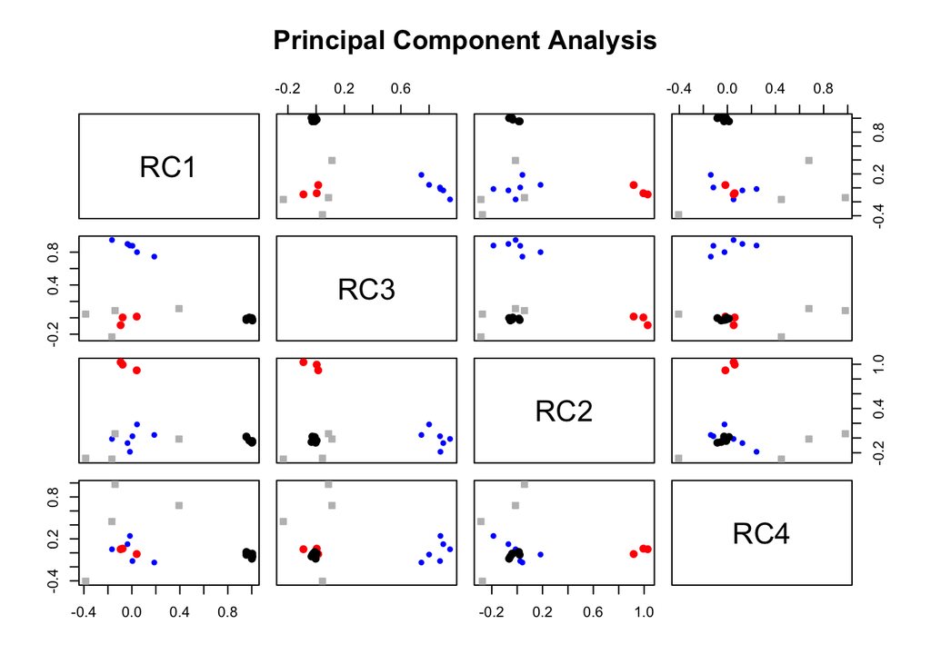

```r
plot(pca_final)
```

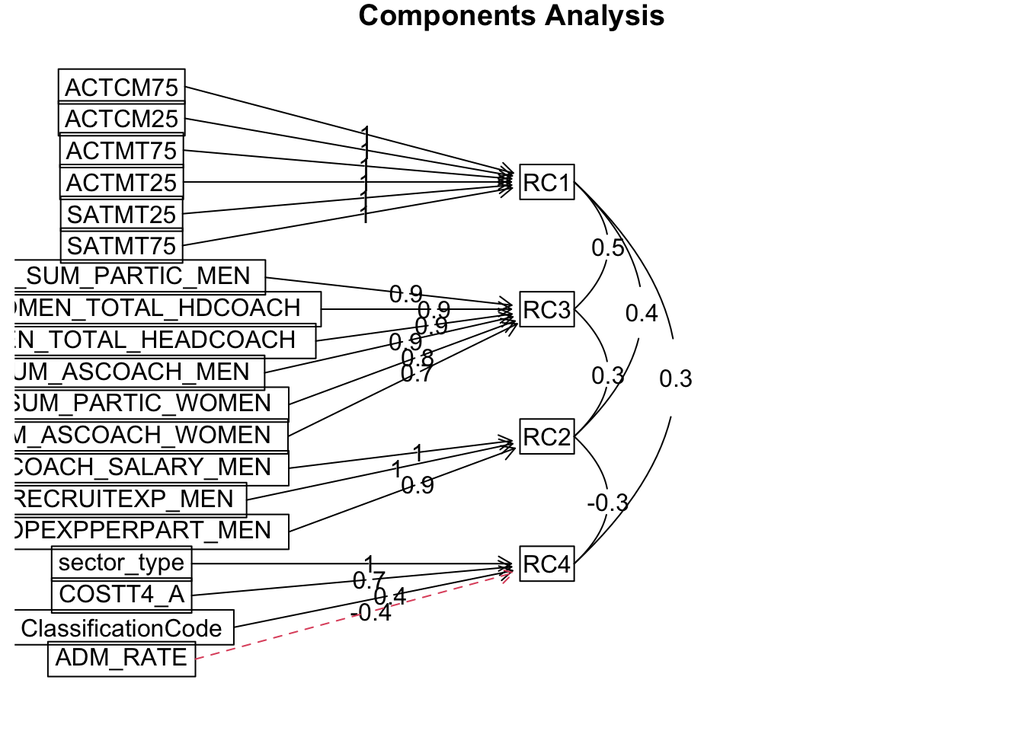

```r
#component 1 is black
#component 3 is blue
#component 2 is red
#component 4 is grey
fa.diagram(pca_final)
```

Component 1: entrance_exam_scores: ACT and SAT scores

Component 2: college_sport_expenditure: coach salary costs for men’s teams, recruitment expenditure for men’s teams, and total expenses per participant for men’s teams

Component 3: numbers_of_coaches_and_participants: the number of head coaches for men’s and women’s teams, the number of assistant coaches for men’s and women’s teams, and the total number of participants in men’s and women’s teams